# Part I - PISA 2012

## Introduction

In this notebook i am going to explore the PISA 2012 dataset. This dataset is the result of PISA study. This study examines how well students have learned the school curriculum, how well prepared they are for life beyond school. Around 510,000 students in 65 economies took part in the PISA 2012 assessment of reading, mathematics and science. Of those economies, 44 took part in an assessment of creative problem solving and 18 in an assessment of financial literacy.

## Preliminary Wrangling

```python
# import all packages and set plots to be embedded inline
import numpy as np
import pandas as pd
import matplotlib.pyplot as plt
import matplotlib as mpl
import seaborn as sb

%matplotlib inline
```

> As the dataset is very large, i decided to view the dictionary in a spreadsheet software and mark those columns out of the 600+ columns in the dataset that i am most interested in. There are specific reasons why i'm interested in these columns which i am to explain soon. Here's a list of these columns by index:

```python
cols_of_interest =[0, 11, 26, 31, 32, 37, 77,
                   78, 187, 192, 199, 205, 222,
                   225, 233, 234, 235, 236, 237, 238, 239, 240, 241, 242,
                   243, 244, 245, 246, 416, 426,
                   471, 480, 490, 550]
```

```python
#Read in PISA dictionary
pisa12_dict = pd.read_csv('pisadict2012.csv', encoding='latin-1')
```

```python
#Select only columns of interest from the dictionary and check if they're correct
pisa12_interest_dict = pisa12_dict.loc[cols_of_interest, :]
pisa12_interest_dict
```

|  | Unnamed: 0 | x |
| --- | --- | --- |
| 0 | CNT | Country code 3-character |
| 11 | ST04Q01 | Gender |
| 26 | ST13Q01 | Mother<Highest Schooling> |
| 31 | ST15Q01 | Mother Current Job Status |
| 32 | ST17Q01 | Father<Highest Schooling> |
| 37 | ST19Q01 | Father Current Job Status |
| 77 | ST35Q04 | Subjective Norms - Parents Believe Studying Ma... |
| 78 | ST35Q05 | Subjective Norms - Parents Believe Mathematics... |
| 187 | ST77Q01 | Math Teaching - Teacher shows interest |
| 192 | ST79Q01 | Teacher-Directed Instruction - Sets Clear Goals |
| 199 | ST79Q08 | Teacher-Directed Instruction - Summarizes Prev... |
| 205 | ST80Q01 | Cognitive Activation - Teacher Encourages to R... |
| 222 | ST83Q01 | Teacher Support - Lets Us Know We Have to Work... |
| 225 | ST83Q04 | Teacher Support - Gives Opportunity to Express... |
| 233 | ST86Q01 | Student-Teacher Relation - Get Along with Teac... |
| 234 | ST86Q02 | Student-Teacher Relation - Teachers Are Intere... |
| 235 | ST86Q03 | Student-Teacher Relation - Teachers Listen to ... |
| 236 | ST86Q04 | Student-Teacher Relation - Teachers Help Students |
| 237 | ST86Q05 | Student-Teacher Relation - Teachers Treat Stud... |
| 238 | ST87Q01 | Sense of Belonging - Feel Like Outsider |
| 239 | ST87Q02 | Sense of Belonging - Make Friends Easily |
| 240 | ST87Q03 | Sense of Belonging - Belong at School |
| 241 | ST87Q04 | Sense of Belonging - Feel Awkward at School |
| 242 | ST87Q05 | Sense of Belonging - Liked by Other Students |
| 243 | ST87Q06 | Sense of Belonging - Feel Lonely at School |
| 244 | ST87Q07 | Sense of Belonging - Feel Happy at School |
| 245 | ST87Q08 | Sense of Belonging - Things Are Ideal at School |
| 246 | ST87Q09 | Sense of Belonging - Satisfied at School |
| 416 | BELONG | Sense of Belonging to School |
| 426 | DISCLIMA | Disciplinary Climate |
| 471 | OUTHOURS | Out-of-School Study Time |
| 480 | TCHBEHSO | Teacher Behaviour: Student Orientation |
| 490 | ANCBELONG | Sense of Belonging to School (Anchored) |
| 550 | W_FSTUWT | FINAL STUDENT WEIGHT |

```python
#From pisa2012.csv load only columns of interest into a dataframe
pisa12 = pd.read_csv('pisa2012.csv', usecols=pisa12_interest_dict.iloc[:,0], encoding='latin-1')
```

```python
#Rename Columns frome encoded names to descriptions in dictionary
pisa12.columns = pisa12_interest_dict.iloc[:,1]
```

```python
#Make adjustments in column names for simplification
pisa12 = pisa12.rename(columns={'Country code 3-character' : 'Country',
                                'Mother<Highest Schooling>' : 'Mother\'s Highest Schooling',
                                'Father<Highest Schooling>' : 'Father\'s Highest Schooling',
                                'Subjective Norms - Parents Believe Studying Mathematics Is Important' :
                                'Parents Believe Studying Mathematics Is Important',
                                'Subjective Norms - Parents Believe Mathematics Is Important for Career' :
                                'Parents Believe Mathematics Is Important for Career',
                                'Math Teaching - Teacher shows interest' : 'Teacher shows interest',
                                'Teacher-Directed Instruction - Sets Clear Goals' : 'Teacher sets Clear Goals',
                                'Teacher-Directed Instruction - Summarizes Previous Lessons' : 'Teacher summarizes Previous Lessons',
                                'Cognitive Activation - Teacher Encourages to Reflect Problems' : 'Teacher encourages to reflect Problems',
                                'Teacher Support - Lets Us Know We Have to Work Hard' : 'Teacher emphasizes Importance of Hard Work',
                                'Teacher Support - Gives Opportunity to Express Opinions' : 'Teacher gives Opportunity to Express Opinions',
                                'Student-Teacher Relation - Get Along with Teachers' : 'Relation - Get Along with Teachers',
                                'Student-Teacher Relation - Teachers Are Interested' : 'Relation - Teachers Are Interested',
                                'Student-Teacher Relation - Teachers Listen to Students' : 'Relation - Teachers Listen to Students',
                                'Student-Teacher Relation - Teachers Help Students' : 'Relation - Teachers Help Students',
                                'Student-Teacher Relation - Teachers Treat Students Fair' : 'Relation - Teachers Treat Students Fair',
                                'FINAL STUDENT WEIGHT' : 'Final student score'
                               })
```

```python
pisa12.info()
```

```
<class 'pandas.core.frame.DataFrame'>
RangeIndex: 485490 entries, 0 to 485489
Data columns (total 34 columns):
 #   Column                                               Non-Null Count   Dtype
---  ------                                               --------------   -----
 0   Country                                              485490 non-null  object
 1   Gender                                               485490 non-null  object
 2   Mother's Highest Schooling                           457979 non-null  object
 3   Mother Current Job Status                            467751 non-null  object
 4   Father's Highest Schooling                           443261 non-null  object
 5   Father Current Job Status                            451410 non-null  object
 6   Parents Believe Studying Mathematics Is Important    315160 non-null  object
 7   Parents Believe Mathematics Is Important for Career  314843 non-null  object
 8   Teacher shows interest                               315248 non-null  object
 9   Teacher sets Clear Goals                             314909 non-null  object
```

[output cut: 26 more lines]

### What is the structure of your dataset?

> Sorted by Country there is one row for each student. In the survey the students were asked about motivational, financial an other circumstances that could influence their results of the mathematic and science assessment. There are categorical variables als well as numerical ones.

### What is/are the main feature(s) of interest in your dataset?

> There are many features of interest in the dataset. A passionate didact could try to make sense of special weaknesses and strengths in different problem types by other factors like country, gender or self concept. A social worker could try and investigate socioeconomic impacts on motivation. The vastness of the dataset allows a broad bandwidth of approaches.

### What features in the dataset do you think will help support your investigation into your feature(s) of interest?

> As a maths teacher in a german school, out of 600+ columns i am mainly interested in **parental factors and the kind of factors that I or we as an educational institution could influence**. Also national differences and gender specific questions arose when I looked at the data. The choice is arbitrary though because there ar many more interesting features in the PISA study.

## Univariate Exploration

### Visualization #1: What does the final score distribution look like? Is it skewed?

```
 [Text(1, 0, '1'),
```

[figure not shown]

```python
plt.figure(figsize=(16, 8))

plt.subplot(1, 2, 1)
sb.histplot(data=pisa12, x='Final student score')
plt.xlim(0, 300)
plt.ylim(0, 3e4)



plt.subplot(1, 2, 2)
bins = 10 ** np.arange(-1, 3.1, 0.1)
sb.histplot(data=pisa12, x='Final student score', bins=bins)
plt.xscale('log')
plt.xlim(2, 1000)
plt.ylim(0, 4e4)
xticks=[1, 3, 10, 30, 100, 300, 1000]
plt.xticks(ticks=xticks, labels=xticks)
```

### Visualiszation #2

```
(0.0, 9000.0)
```

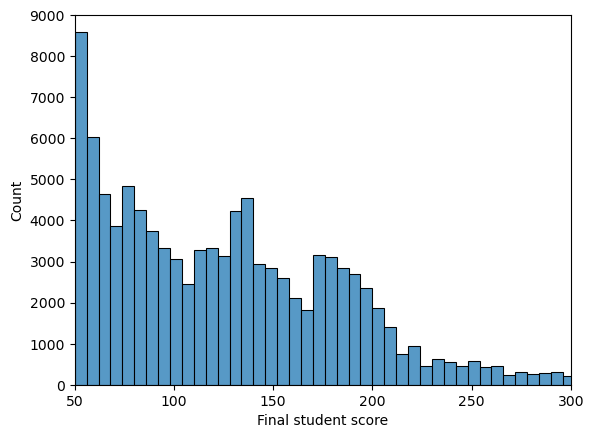

```python
bins = np.arange(50, 300+6, 6)
sb.histplot(data=pisa12, bins=bins, x='Final student score')
plt.xlim(50, 300)
plt.ylim(0, 9e3)
```

### Visualization #3: What countries have the highest number of participants?

```
(array([ 0,  1,  2,  3,  4,  5,  6,  7,  8,  9, 10, 11, 12, 13, 14, 15, 16,
        17, 18, 19, 20, 21, 22, 23, 24, 25, 26, 27, 28, 29, 30, 31, 32, 33,
        34, 35, 36, 37, 38, 39, 40, 41, 42, 43, 44, 45, 46, 47, 48, 49, 50,
        51, 52, 53, 54, 55, 56, 57, 58, 59, 60, 61, 62, 63, 64, 65, 66, 67]),
 [Text(0, 0, 'Mexico'),
```

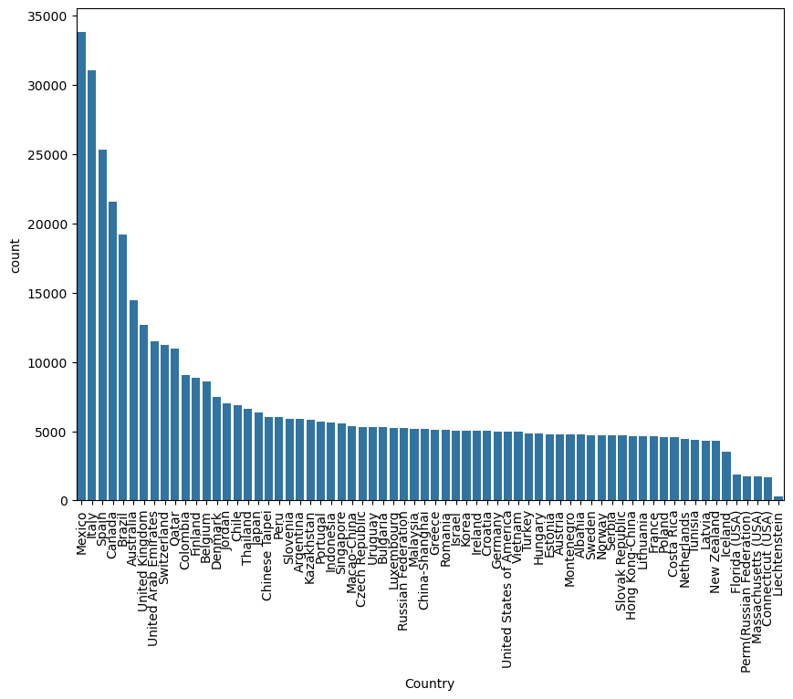

```python
country_order = pisa12['Country'].value_counts().index
plt.figure(figsize=(10,7))
base_color = sb.color_palette()[0]
sb.countplot(data=pisa12, x='Country', order=country_order, color=base_color)
plt.xticks(rotation=90)
```

### Visualization #4: Are genders equally represented?

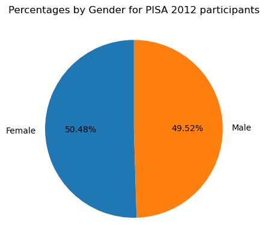

```python
gender_counts = pisa12['Gender'].value_counts()
plt.pie(gender_counts, labels=['Female', 'Male'], autopct='%1.2f%%', startangle=90)
plt.title('Percentages by Gender for PISA 2012 participants')
```

### Discuss the distribution(s) of your variable(s) of interest. Were there any unusual points? Did you need to perform any transformations?

> **Observation 1**: The initial automatic distribution of final scores is highly right skewed. There are relatively very few results above 250 but some are even much higher than that. To get a sense of the distribution you should limit both axes.

> **Observation 2**: There seem to be a lot of students with a score of 0 or close to 0. This observation is difficult to interpret which is why I I limited the x-axis to a score of 50 or higher. I found out there were kind of different local modes in the distribution with one mode close to 0, the next around 75, another around 130 and yet another one around 170/180. The peaks tend to get smaller so the distribution as a shape that looks like four waves getting smaller consecutively.

> **Observation 3**: Countries with most participants are Mexico, Italy, Spain, Canada, Brazil. Most countries have around 5000 participants. Choosing representative samples I assume 5000 to be enough to get valid results, even for large countries. Maybe the countries with large numbers did this for national study purposes.

> **Oberservation 4**: There are slightly more girls than boys in the dataset. This should overall be a good representation since there are more women than men in the world.

### Of the features you investigated, were there any unusual distributions? Did you perform any operations on the data to tidy, adjust, or change the form of the data? If so, why did you do this?

> I tried a log-scaled score-axis in the first visualisation which reveals a kind of tri-modal distribution with peaks on 0 Points and 10-30 Points. These are difficult to interpret to me. Thus i did'nt draw any meaningful observation from the log-scaled histogram.

> I had to adjust bins and axis limits for the second final score distribution. Otherwise one could hardly see the multimodal structure of the distribution.

> I had to bring the value counts of the countries in order and enlarge the figure. Without ordered value counts it's harder to see which countries have the most participants and that many countries have almost equally many participants.

## Bivariate Exploration

> In this section, investigate relationships between pairs of variables in your data. Make sure the variables that you cover here have been introduced in some fashion in the previous section (univariate exploration).

### Visualization #5: Does gender affect PISA score?

```
(0.0, 320.0)
```

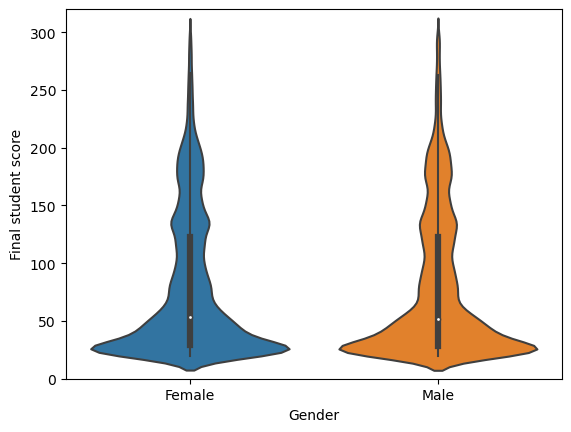

```python
pisa12_lim = pisa12[pisa12['Final student score'].between(20, 300)]
sb.violinplot(data=pisa12_lim, x='Gender', y='Final student score')
plt.ylim(0, 320)
```

### Visualizations #6-#9: Does Parent's socioeconomic backgroud correlate with final scores?

```python
#Set bar order level
levels_order_mother = ['She did not complete <ISCED level 1> ',
                '<ISCED level 1> ',
                '<ISCED level 2> ',
                '<ISCED level 3A> ',
                '<ISCED level 3B, 3C> ']
levels_order_father = ['He did not complete <ISCED level 1> ',
                '<ISCED level 1> ',
                '<ISCED level 2> ',
                '<ISCED level 3A> ',
                '<ISCED level 3B, 3C> ']

#Normalize entries in job statuses
pisa12.loc[pisa12['Mother Current Job Status'].str.contains('Not', na=False), 'Mother Current Job Status'] = 'Looking for a job'
pisa12.loc[pisa12['Mother Current Job Status'].str.contains('part', na=False), 'Mother Current Job Status'] = 'Working part-time'
pisa12.loc[pisa12['Mother Current Job Status'].str.contains('full', na=False), 'Mother Current Job Status'] = 'Working full-time'
pisa12.loc[pisa12['Mother Current Job Status'].str.contains('Other', na=False), 'Mother Current Job Status'] = 'Other'

pisa12.loc[pisa12['Father Current Job Status'].str.contains('Not', na=False), 'Father Current Job Status'] = 'Looking for a job'
pisa12.loc[pisa12['Father Current Job Status'].str.contains('part', na=False), 'Father Current Job Status'] = 'Working part-time'
pisa12.loc[pisa12['Father Current Job Status'].str.contains('full', na=False), 'Father Current Job Status'] = 'Working full-time'
pisa12.loc[pisa12['Father Current Job Status'].str.contains('Other', na=False), 'Father Current Job Status'] = 'Other'

#Set Bar order status
status_order = ['Looking for a job',
                'Working part-time',
                'Working full-time',
                'Other']
```

```
(array([0, 1, 2, 3]),
 [Text(0, 0, 'Looking for a job'),
```

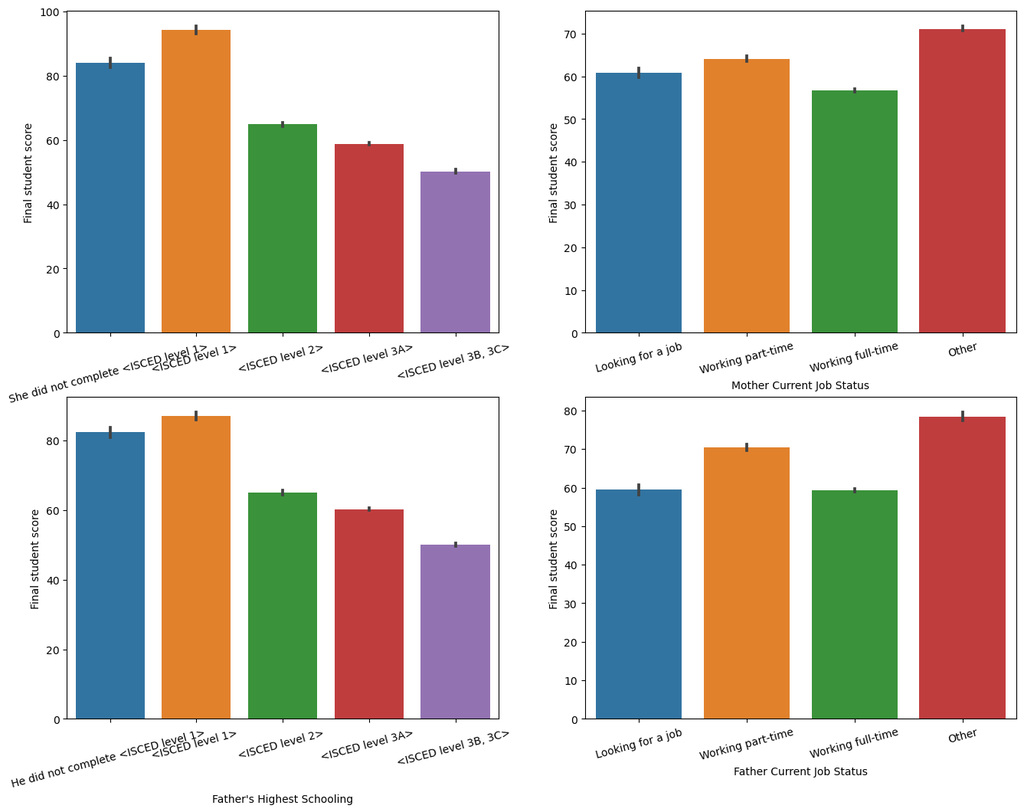

```python
plt.figure(figsize=(16,12))
pisa12_lim = pisa12[pisa12['Final student score'].between(10, 500)]


plt.subplot(2, 2, 1)
sb.barplot(data=pisa12_lim, x='Mother\'s Highest Schooling', y='Final student score', order=levels_order_mother)
plt.xticks(rotation=15)

plt.subplot(2, 2, 2)
sb.barplot(data=pisa12_lim, x='Mother Current Job Status', y='Final student score', order=status_order)
plt.xticks(rotation=15)

plt.subplot(2, 2, 3)
sb.barplot(data=pisa12_lim, x='Father\'s Highest Schooling', y='Final student score', order=levels_order_father)
plt.xticks(rotation=15)

plt.subplot(2, 2, 4)
sb.barplot(data=pisa12_lim, x='Father Current Job Status', y='Final student score', order=status_order)
plt.xticks(rotation=15)
```

### Visualiszation #10: Does Parent's attitude correlate with final student score?

```python
pisa12['Parents Believe Studying Mathematics Is Important'].unique()
```

```
array(['Agree', 'Strongly agree', nan, 'Disagree', 'Strongly disagree'],
      dtype=object)
```

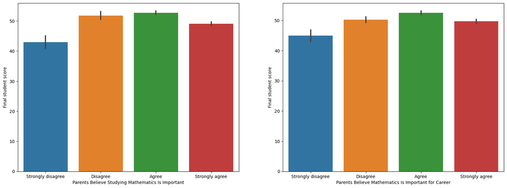

```python
plt.figure(figsize=(20,7))
attitudes_order = ['Strongly disagree', 'Disagree', 'Agree', 'Strongly agree']

plt.subplot(1, 2, 1)
sb.barplot(data=pisa12,
           x='Parents Believe Studying Mathematics Is Important',
           y='Final student score',
           order=attitudes_order)

plt.subplot(1, 2, 2)
sb.barplot(data=pisa12,
           x='Parents Believe Mathematics Is Important for Career',
           y='Final student score',
           order=attitudes_order)
```

### Visualization #11: Do Sense of belonging to school and final student score correlate?

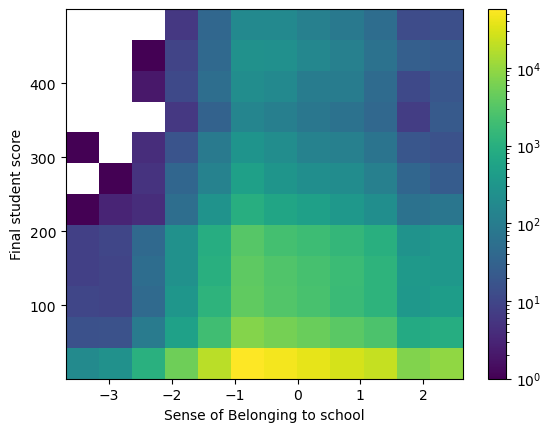

```python
pisa12_belong = pisa12[pisa12['Sense of Belonging to School'].notnull() & pisa12['Final student score'].between(0,500)]

plt.hist2d(data=pisa12_belong, x='Sense of Belonging to School', y='Final student score', norm=mpl.colors.LogNorm(), bins=12)
plt.xlabel('Sense of Belonging to school')
plt.ylabel('Final student score')

plt.colorbar()
```

### Visualizations #12-#17: Does teacher's behavior/communication correlate with a sense of belonging to school?

```
(array([0, 1, 2, 3]),
 [Text(0, 0, 'Strongly disagree'),
```

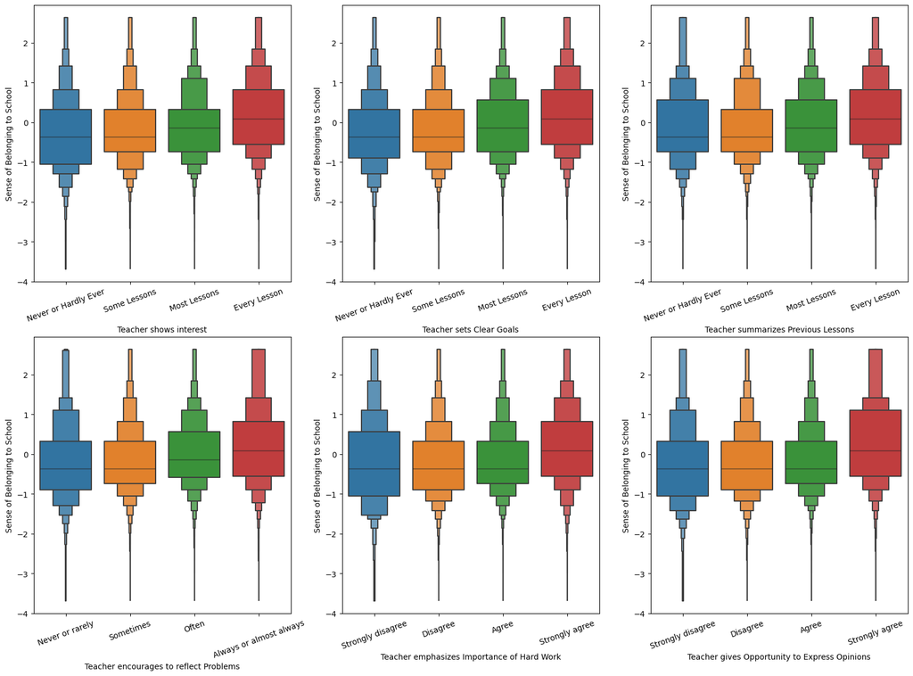

```python
#Choose only nonnull-Values
pisa12_teacher = pisa12[pisa12['Teacher shows interest'].notnull()]
frequency_order = ['Never or Hardly Ever', 'Some Lessons', 'Most Lessons', 'Every Lesson']


#Create figure for six diagrams
plt.figure(figsize=(20,14))

plt.subplot(2, 3, 1)
sb.boxenplot(data=pisa12_teacher, x='Teacher shows interest', y='Sense of Belonging to School', order=frequency_order)
plt.xticks(rotation=20)

plt.subplot(2, 3, 2)
sb.boxenplot(data=pisa12_teacher, x='Teacher sets Clear Goals', y='Sense of Belonging to School', order=frequency_order)
plt.xticks(rotation=20)

plt.subplot(2, 3, 3)
sb.boxenplot(data=pisa12_teacher, x='Teacher summarizes Previous Lessons', y='Sense of Belonging to School', order=frequency_order)
plt.xticks(rotation=20)

plt.subplot(2, 3, 4)
reflect_order=['Never or rarely', 'Sometimes', 'Often', 'Always or almost always']
sb.boxenplot(data=pisa12_teacher, x='Teacher encourages to reflect Problems', y='Sense of Belonging to School', order=reflect_order)
plt.xticks(rotation=20)

plt.subplot(2, 3, 5)
accordance_order=['Strongly disagree', 'Disagree', 'Agree', 'Strongly agree']
sb.boxenplot(data=pisa12_teacher, x='Teacher emphasizes Importance of Hard Work', y='Sense of Belonging to School', order=accordance_order)
plt.xticks(rotation=20)

plt.subplot(2, 3, 6)
sb.boxenplot(data=pisa12_teacher, x='Teacher gives Opportunity to Express Opinions', y='Sense of Belonging to School', order=accordance_order)
plt.xticks(rotation=20)
```

### Talk about some of the relationships you observed in this part of the investigation. How did the feature(s) of interest vary with other features in the dataset?

> Observations #5 - #9: Since there are many final student weights close to zero, which is hardly interpretable, i played around a lot with the ranges of final student scores i wanted to accept for comparison with parents socioeconomic background. I cannot display all of the ranges i tried and different ranges almost always led to different observations. **Still i found a couple of interesting obersvations**: First, almost all ranges i tried showed a relatively low score of students whose parents' ISCED level is "3B, 3C", which is the highest educational level in the data. Second, there is a correlation between parents' job status "Other" and high scores. Looking for an explanation for the latter i guess "Other" might include entrepreneurs and "self-made" people, which could mean there are quite a lot upper class students. Third, students with full-time working parents have relatively bad scores. Getting more or less support by parents at home might have an effect!

> Obersvation #10: Visualization #10 shows - interestingly - that if parents strongly agree that mathematics is important, students are worse than if parents only "Agree". Too much pressure influencing students learning behaviour in several possible ways here might be an issue.

> Observations #12 - #17: Finally visualizations #12 - #17 show how teachers specific engagements correlate to a general sense of belonging to school. Most effective means are encouraging to reflect problems and giving the opportunity to express opinions. It seems to me that those are the features which mostly support a good relationship between students an teachers which might be an explanation for the observation. Overall the six features are part of broader teacher-related features we can find in the original dataset: "Teacher Behaviour: Formative Assessment", "Teacher Behaviour: Student Orientation", "Teacher Behaviour: Teacher-directed Instruction" and "Teacher Support".

### Did you observe any interesting relationships between the other features (not the main feature(s) of interest)?

> I did not find any observable difference in scores of males and females.

## Multivariate Exploration

> Create plots of three or more variables to investigate your data even further. Make sure that your investigations are justified, and follow from your work in the previous sections.

```python
pisa12.info()
```

```
<class 'pandas.core.frame.DataFrame'>
RangeIndex: 485490 entries, 0 to 485489
Data columns (total 34 columns):
 #   Column                                               Non-Null Count   Dtype
---  ------                                               --------------   -----
 0   Country                                              485490 non-null  object
 1   Gender                                               485490 non-null  object
 2   Mother's Highest Schooling                           457979 non-null  object
 3   Mother Current Job Status                            467751 non-null  object
 4   Father's Highest Schooling                           443261 non-null  object
 5   Father Current Job Status                            451410 non-null  object
 6   Parents Believe Studying Mathematics Is Important    315160 non-null  object
 7   Parents Believe Mathematics Is Important for Career  314843 non-null  object
 8   Teacher shows interest                               315248 non-null  object
 9   Teacher sets Clear Goals                             314909 non-null  object
```

[output cut: 26 more lines]

### Visualization #18: What impact on final scores do a sense of belonging to school and student oriented teaching have?

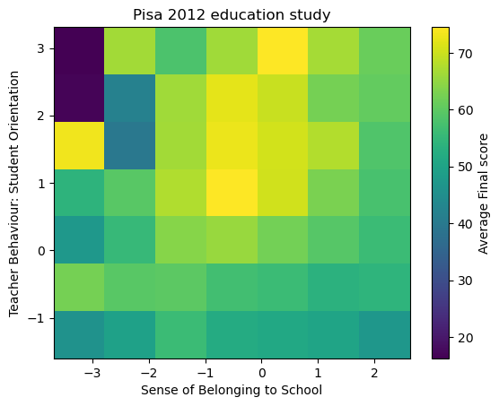

```python
#Define number of bins for 2d-histogram
belong_min = pisa12['Sense of Belonging to School'].min()
belong_max = pisa12['Sense of Belonging to School'].max()
belong_binwidth = (belong_max - belong_min)/7

teach_min = pisa12['Teacher Behaviour: Student Orientation'].min()
teach_max = pisa12['Teacher Behaviour: Student Orientation'].max()
teach_binwidth = (teach_max - teach_min)/7

bins_x = np.arange(belong_min, belong_max+belong_binwidth, belong_binwidth)
bins_y = np.arange(teach_min, teach_max+teach_binwidth, teach_binwidth)

pisa12_bt = pisa12[pisa12['Sense of Belonging to School'].notnull()
                   & pisa12['Teacher Behaviour: Student Orientation'].notnull()
                   & pisa12['Final student score'].between(10, 500)]


# Determine which bin for each point
belong_bins = pd.cut(pisa12_bt['Sense of Belonging to School'],
                     bins_x, right = False,
                     include_lowest = False,
                     labels = False).astype(int)
teach_bins = pd.cut(pisa12_bt['Teacher Behaviour: Student Orientation'],
                    bins_y, right = False,
                    include_lowest = False,
                    labels = False).astype(int)

# Count the points in each bin
n_points = pisa12.groupby([belong_bins, teach_bins]).size()
n_points = n_points.reset_index().pivot(index = 'Sense of Belonging to School', columns = 'Teacher Behaviour: Student Orientation').values

# Divide final scores by the number of points in each bin
student_score_weights = pisa12_bt['Final student score'] / n_points[belong_bins, teach_bins]

plt.hist2d(data=pisa12_bt,
           x='Sense of Belonging to School',
           y='Teacher Behaviour: Student Orientation',
           bins=[bins_x, bins_y],
           cmin=0,
           cmap='viridis',
           weights=student_score_weights
           )

plt.colorbar(label='Average Final score')
plt.xlabel('Sense of Belonging to School')
plt.ylabel('Teacher Behaviour: Student Orientation')
plt.title('Pisa 2012 education study')
```

### Visualization #19: As sense of belonging to school and teacher's student orientation seem to be correlated quite obviously, we could'nt observe very strong interactions. But how about disciplinary climate and teachers student orientation?

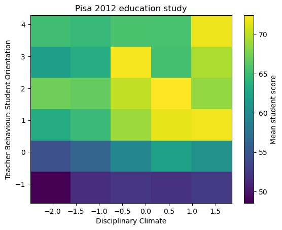

```python
#Define number of bins for 2d-histogram
discipl_min = pisa12['Disciplinary Climate'].min()
discipl_max = pisa12['Disciplinary Climate'].max()
discipl_binwidth = (discipl_max - discipl_min)/5

teach_min = pisa12['Teacher Behaviour: Student Orientation'].min()
teach_max = pisa12['Teacher Behaviour: Student Orientation'].max()
teach_binwidth = (teach_max - teach_min)/5

bins_x = np.arange(discipl_min, discipl_max+1*discipl_binwidth, discipl_binwidth)
bins_y = np.arange(teach_min, teach_max+2*teach_binwidth, teach_binwidth)

pisa12_bt = pisa12[pisa12['Disciplinary Climate'].notnull()
                   & pisa12['Teacher Behaviour: Student Orientation'].notnull()
                   & pisa12['Final student score'].between(10, 500)]


# Determine which bin for each point
discipl_bins = pd.cut(pisa12_bt['Disciplinary Climate'],
                     bins_x, right = False,
                     include_lowest = False,
                     labels = False).astype(int)
teach_bins = pd.cut(pisa12_bt['Teacher Behaviour: Student Orientation'],
                    bins_y, right = False,
                    include_lowest = False,
                    labels = False).astype(int)

# Count the points in each bin
n_points = pisa12.groupby([discipl_bins, teach_bins]).size()
n_points = n_points.reset_index().pivot(index = 'Disciplinary Climate', columns = 'Teacher Behaviour: Student Orientation').values

# Divide final scores by the number of points in each bin
student_score_weights = pisa12_bt['Final student score'] / n_points[discipl_bins, teach_bins]

plt.hist2d(data=pisa12_bt,
           x='Disciplinary Climate',
           y='Teacher Behaviour: Student Orientation',
           bins=[bins_x, bins_y],
           cmin=0,
           cmap='viridis',
           weights=student_score_weights
           )

plt.colorbar(label='Mean student score')
plt.xlabel('Disciplinary Climate')
plt.ylabel('Teacher Behaviour: Student Orientation')
plt.title('Pisa 2012 education study')
```

### Visualization #20: How do scores and out of school study-time correlate, depending on Parents job status?

```python
#Build sample with equally many students of each of mother's job status'
sample = pisa12[pisa12['Mother Current Job Status']=='Looking for a job'].sample(6000).merge(
         pisa12[pisa12['Mother Current Job Status']=='Working part-time'].sample(6000).merge(
         pisa12[pisa12['Mother Current Job Status']=='Working full-time'].sample(6000).merge(
         pisa12[pisa12['Mother Current Job Status']=='Other'].sample(6000), how='outer'), how='outer'), how='outer')
```

```
 [])
```

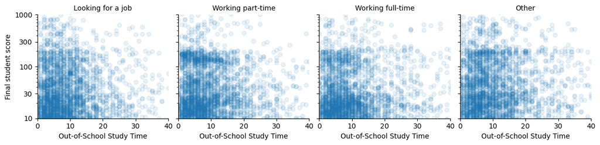

```python
g = sb.FacetGrid(data=sample, col='Mother Current Job Status', col_order=status_order)
g.map(plt.scatter, 'Out-of-School Study Time', 'Final student score', alpha=0.1)
g.set_titles(col_template="{col_name}")

plt.xlim(0,40)
plt.ylim(10,1000)
plt.yscale('log')
yticks=[10, 30, 100, 300, 1000]
plt.yticks(ticks=yticks, labels=yticks)
```

```python
#Build sample with equally many students of each of father's job status'
sample = pisa12[pisa12['Father Current Job Status']=='Looking for a job'].sample(6000).merge(
         pisa12[pisa12['Father Current Job Status']=='Working part-time'].sample(6000).merge(
         pisa12[pisa12['Father Current Job Status']=='Working full-time'].sample(6000).merge(
         pisa12[pisa12['Father Current Job Status']=='Other'].sample(6000), how='outer'), how='outer'), how='outer')
```

```
 [])
```

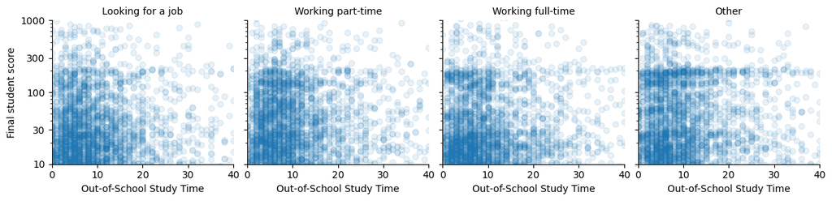

```python
g = sb.FacetGrid(data=sample, col='Father Current Job Status', col_order=status_order)
g.map(plt.scatter, 'Out-of-School Study Time', 'Final student score', alpha=0.1)
g.set_titles(col_template="{col_name}")

plt.xlim(0,40)
plt.ylim(10,1000)
plt.yscale('log')
yticks=[10, 30, 100, 300, 1000]
plt.yticks(ticks=yticks, labels=yticks)
```

```python
pisa12.info()
```

```
<class 'pandas.core.frame.DataFrame'>
RangeIndex: 485490 entries, 0 to 485489
Data columns (total 34 columns):
 #   Column                                               Non-Null Count   Dtype
---  ------                                               --------------   -----
 0   Country                                              485490 non-null  object
 1   Gender                                               485490 non-null  object
 2   Mother's Highest Schooling                           457979 non-null  object
 3   Mother Current Job Status                            467751 non-null  object
 4   Father's Highest Schooling                           443261 non-null  object
 5   Father Current Job Status                            451410 non-null  object
 6   Parents Believe Studying Mathematics Is Important    315160 non-null  object
 7   Parents Believe Mathematics Is Important for Career  314843 non-null  object
 8   Teacher shows interest                               315248 non-null  object
 9   Teacher sets Clear Goals                             314909 non-null  object
```

[output cut: 26 more lines]